# HOMEWORK_004

Mike James

March 16, 2019

### Problem 1

#### Justification

> A marine biologist is researching the seasonal effect on reproductive strategies of limpets as a function of intraspecific competition. He set cages for the limpets in intertidal pools in California. Each of the cages had a different density of limpets (8, 15, 30 and 45), He measured the the mass of the egg clusters and log-transformed them to meet the assumptions of the test. Are there any detectable effects?

Looking at the normalized boxplots (see **results** section below), the egg density appears to be higher in the spring than in the summer season.

#### Results

```r
limpet <- read.csv('h5p1.csv')
summary(limpet)
```

```
##     DENSITY         SEASON        EGGS
##  Min.   : 8.00   spring:72   Min.   :0.3204
##  1st Qu.:13.25   summer:72   1st Qu.:0.9297
##  Median :22.50               Median :1.4680
##  Mean   :24.50               Mean   :1.5317
##  3rd Qu.:33.75               3rd Qu.:2.0356
##  Max.   :45.00               Max.   :3.2825
```

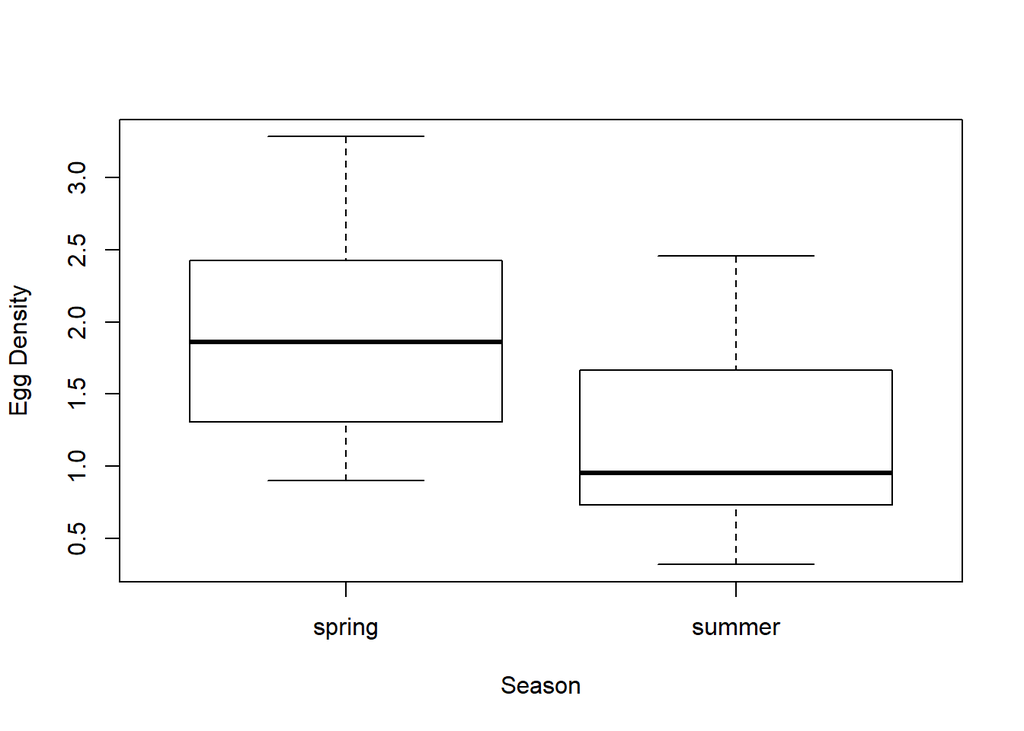

```r
boxplot(limpet$EGGS~limpet$SEASON, xlab = "Season", ylab = "Egg Density")
```

As referenced above, the boxplot shows the egg density in the spring as being higher than in the summer.

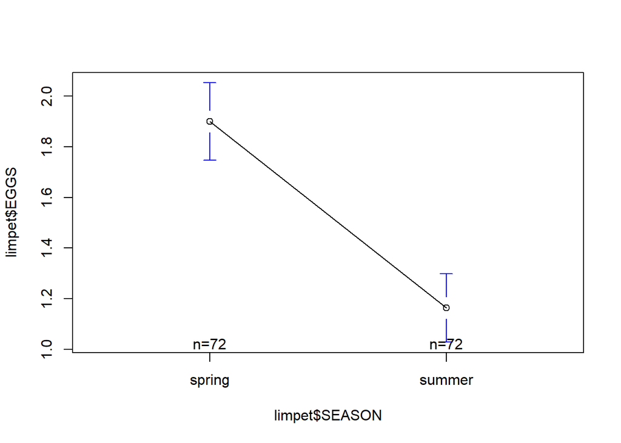

```r
plotmeans(limpet$EGGS~limpet$SEASON)
```

Even though the line connecting the two means is useless, this too shows a higher egg density in the spring vs. the summer

```r
(limpetaov <- aov(limpet$EGGS~limpet$SEASON))
```

```
## Call:
##    aov(formula = limpet$EGGS ~ limpet$SEASON)
##
## Terms:
##                 limpet$SEASON Residuals
## Sum of Squares       19.50106  53.24320
## Deg. of Freedom             1       142
##
## Residual standard error: 0.6123333
## Estimated effects may be unbalanced
```

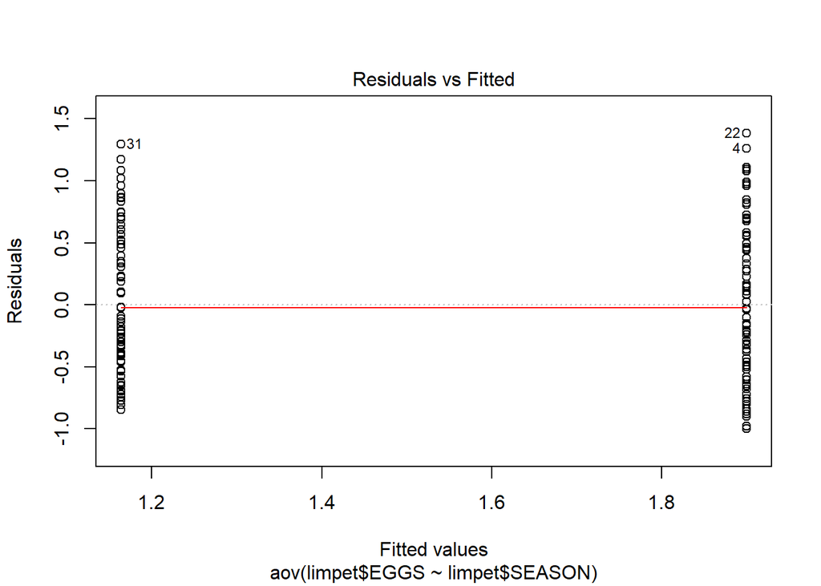

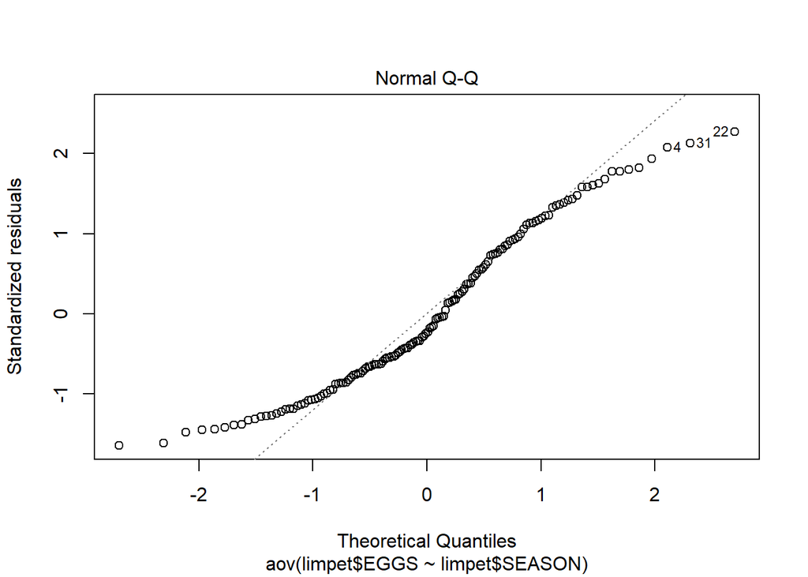

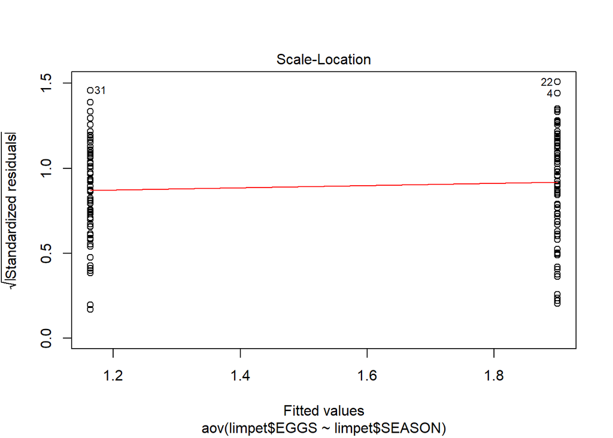

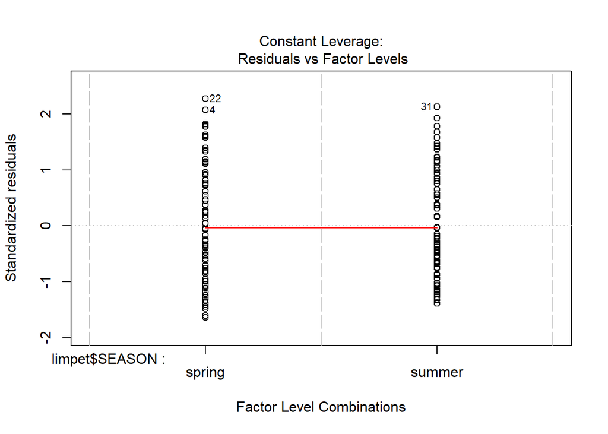

```r
plot(limpetaov)
```

Here we see the residuals vs fitted having equal variance.

According to the qq plot, resuduals drop off in the upper quantiles and are slightly higher in the lower quantiles.

Looking at the scale-location plot, we can see a *slight* increase in residuals with respect to the fitted values.

And the constant leverage shows all factors are well fit.

```r
bartlett.test(limpet$EGGS~limpet$SEASON)
```

```
##
##  Bartlett test of homogeneity of variances
##
## data:  limpet$EGGS by limpet$SEASON
## Bartlett's K-squared = 1.0234, df = 1, p-value = 0.3117
```

For the Bartlett test, we see that the p-value is 0.3117, which does not allow us to reject the null hypothesis; meaning the variance is the same for all groups.

```r
t.test(limpet$EGGS~limpet$SEASON)
```

```
##
##  Welch Two Sample t-test
##
## data:  limpet$EGGS by limpet$SEASON
## t = 7.2118, df = 139.98, p-value = 3.165e-11
## alternative hypothesis: true difference in means is not equal to 0
## 95 percent confidence interval:
##  0.5342305 0.9377695
## sample estimates:
## mean in group spring mean in group summer
##              1.89975              1.16375
```

Here, the Welch t-test p-value allows us to reject the null hypothesis that the means are equal between the two seasons.

#### Conclusion

According to all results, the seasons **do** affect the egg density of limpets.

### Problem 2

#### Justification

> A botany student is interested in how productivity in tomato plants responds to soil microbial amendments. He uses three levels of a commercial variety that claims to improve productivity. He then proceeds to place fifteen plants in each of five greenhouses across campus and he labels those according to orientation. Determine if there are significant effects due to the soil treatment.

The boxplot below shows the low and medium amendments having roughly the same mean while the high amendment treatment shows a higher mean.

#### Results

```r
tomatoes <- read.csv('h5.p2.csv')
summary(tomatoes)
```

```
##  Greenhouse Soil.mix   productivity
##  NE:45      high:75   Min.   : 2.050
##  NW:45      low :75   1st Qu.: 6.660
##  S :45      med :75   Median : 7.770
##  SE:45                Mean   : 8.018
##  W :45                3rd Qu.: 9.640
##                       Max.   :13.820
```

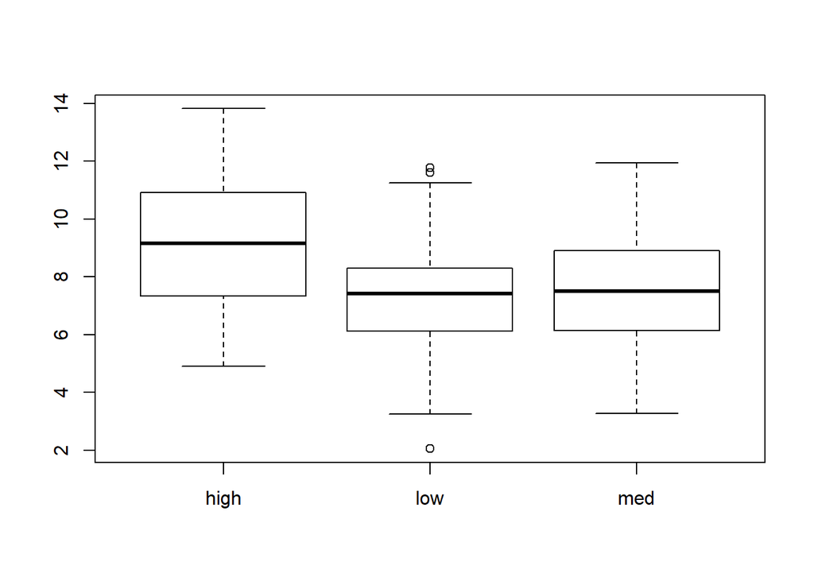

```r
boxplot(tomatoes$productivity~tomatoes$Soil.mix)
```

As mentioned above, this boxplot shows the **high** amendment having a greater productivity than both the low and medium amendments.

```r
(tomaov <- aov(tomatoes$productivity~tomatoes$Soil.mix))
```

```
## Call:
##    aov(formula = tomatoes$productivity ~ tomatoes$Soil.mix)
##
## Terms:
##                 tomatoes$Soil.mix Residuals
## Sum of Squares           176.3173 1002.3506
## Deg. of Freedom                 2       222
##
## Residual standard error: 2.124875
## Estimated effects may be unbalanced
```

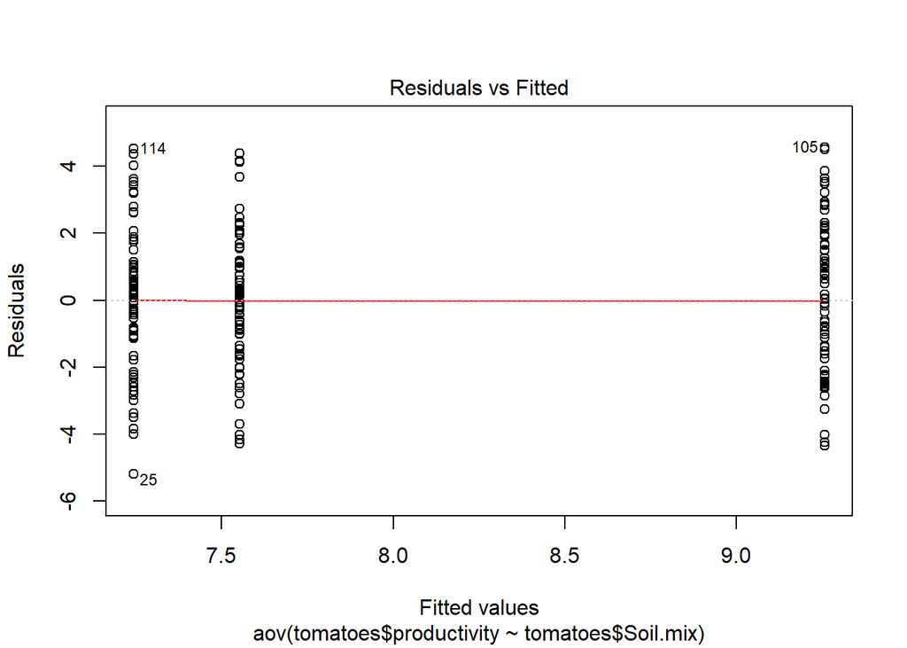

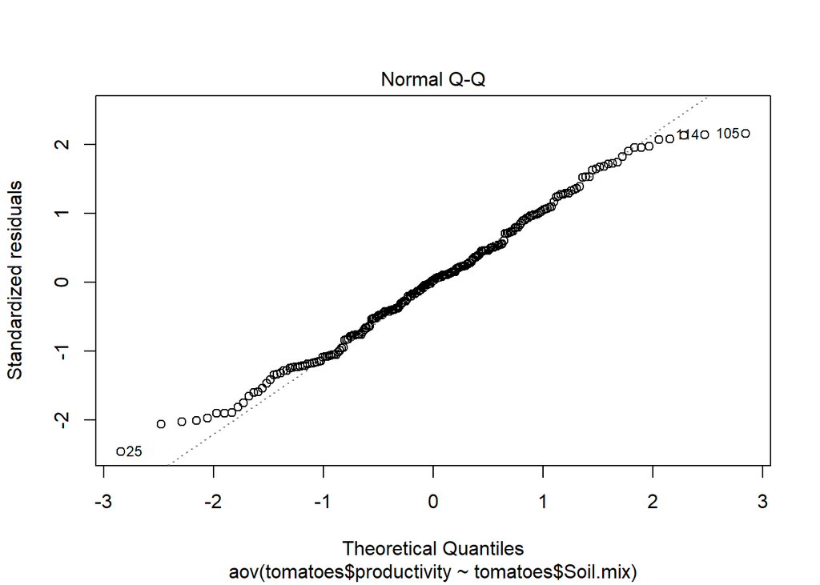

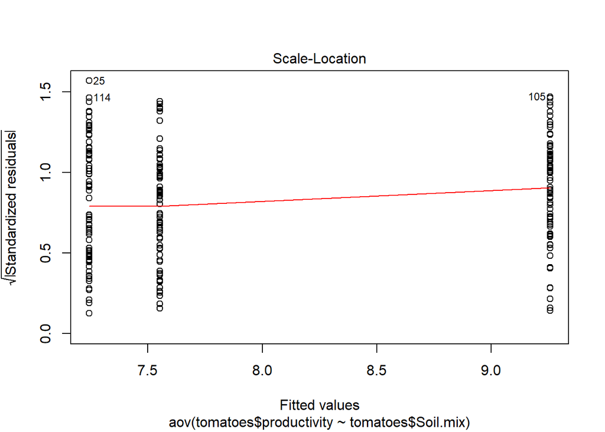

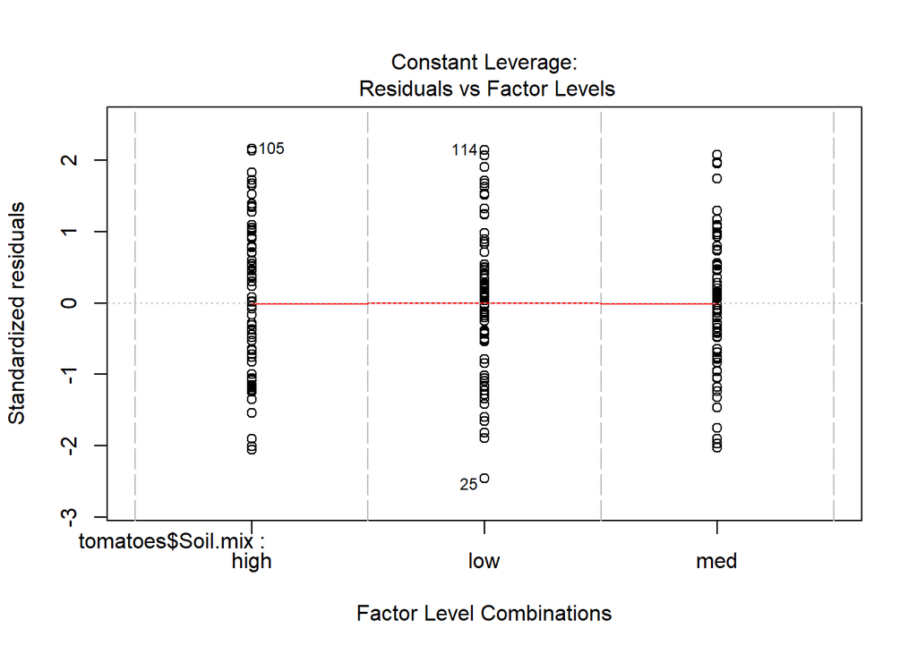

```r
plot(tomaov)
```

Our residuals vs. the fitted data show a similar scatter for all, meaning variance is equal.

The qq-plot shows a slight elevation of residuals at the lower quantiles and a decrease at the upper quantiles.

There is a slight increase in residuals with the fitted values according to the scale-location plot.

And the constant leverage plot shows equally fitted values for the factors.

```r
anova(aov(tomatoes$productivity~tomatoes$Soil.mix))
```

```
## Analysis of Variance Table
##
## Response: tomatoes$productivity
##                    Df  Sum Sq Mean Sq F value    Pr(>F)
## tomatoes$Soil.mix   2  176.32  88.159  19.525 1.544e-08 ***
## Residuals         222 1002.35   4.515
## ---
## Signif. codes:  0 '***' 0.001 '**' 0.01 '*' 0.05 '.' 0.1 ' ' 1
```

```r
bartlett.test(tomatoes$productivity~tomatoes$Soil.mix)
```

```
##
##  Bartlett test of homogeneity of variances
##
## data:  tomatoes$productivity by tomatoes$Soil.mix
## Bartlett's K-squared = 0.83363, df = 2, p-value = 0.6591
```

According to the Bartlett test, we have a p-value of 0.6591; meaning, we cannot reject the null hypothesis that the variances are the same.

```r
TukeyHSD(aov(tomatoes$productivity~tomatoes$Soil.mix))
```

```
##   Tukey multiple comparisons of means
##     95% family-wise confidence level
##
## Fit: aov(formula = tomatoes$productivity ~ tomatoes$Soil.mix)
##
## $`tomatoes$Soil.mix`
##                diff        lwr        upr     p adj
## low-high -2.0130667 -2.8318056 -1.1943278 0.0000001
## med-high -1.7044000 -2.5231389 -0.8856611 0.0000052
## med-low   0.3086667 -0.5100722  1.1274056 0.6474645
```

According to Tukey HSD, there is a significant difference in means between the low-high and med-high amendments. Tukey HSD also shows there is no significant difference in means betwixt the medium and low amendments.

#### Conclusion

According to the results, there is a significant difference between the high amendment treatment and the low/medium amendments. There is **not**, however, a significant difference between the low and medium amendments.